# Introdução ao R

Fernando Meireles

Universidade Federal de Minas Gerais

# Introdução ao R: Básico

O R é um ambiente de programação estatístico, mas também é uma linguagem de programação de alto nível:

- É um *ambiente* porque foi planejado com um conjunto de funcionalidades relacionadas e adaptáveis;
- É uma *linguagem de programação* porque permite criar e modificar funções, além de alterar objetos nela;
- É de *alto nível* porque não requer do usuário empregar código binário;

# Introdução ao R: O que ele faz?

Por ser uma linguagem de programação, é possível fazer praticamente tudo com o R:

- Criar e usar funções;
- Abrir, modificar, criar e salvar qualquer tipo de arquivo;
- Conectar-se à internet;
- Interagir com outros recursos num computador ou servidor.

# Introdução ao R: O que ele faz?

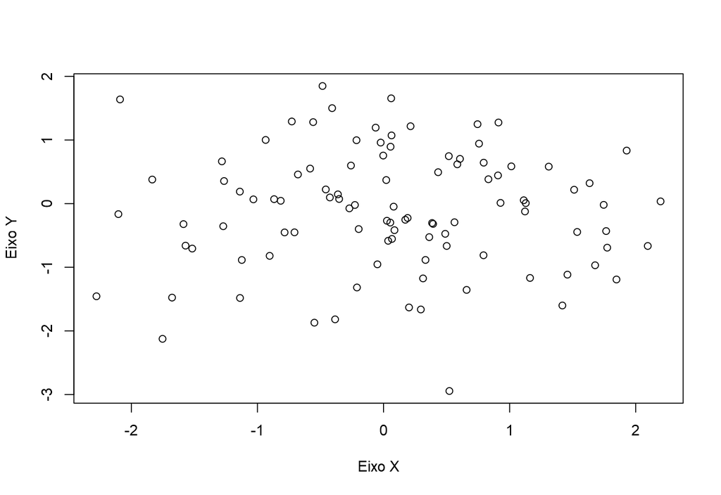

# Introdução ao R: O que ele faz?

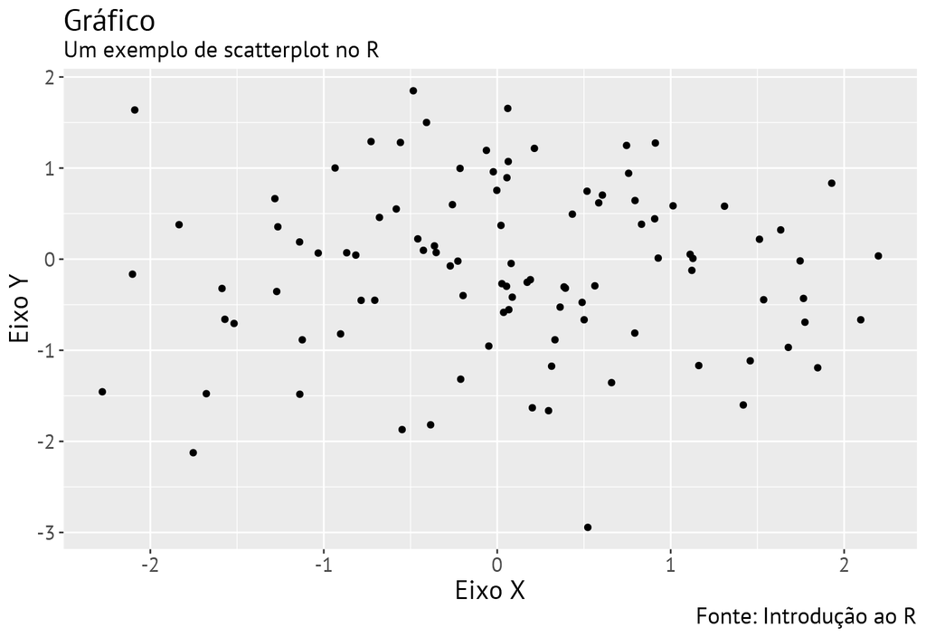

# Introdução ao R: O que ele faz?

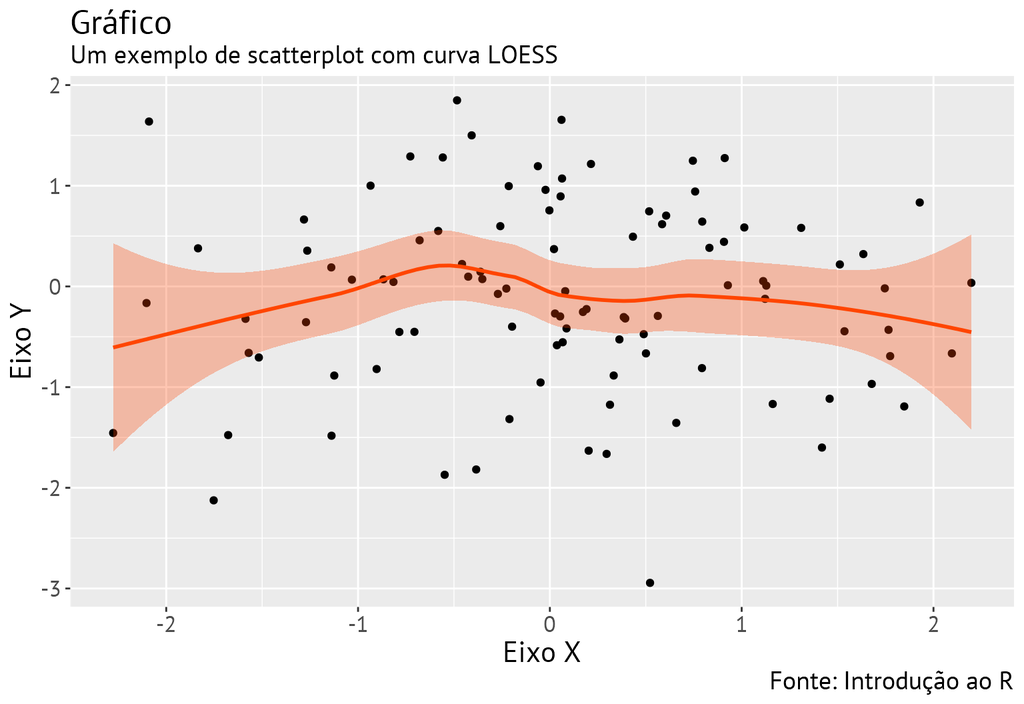

# Introdução ao R: O que ele faz?

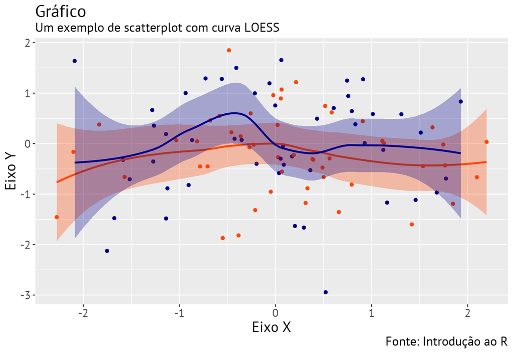

# Introdução ao R: O que ele faz?

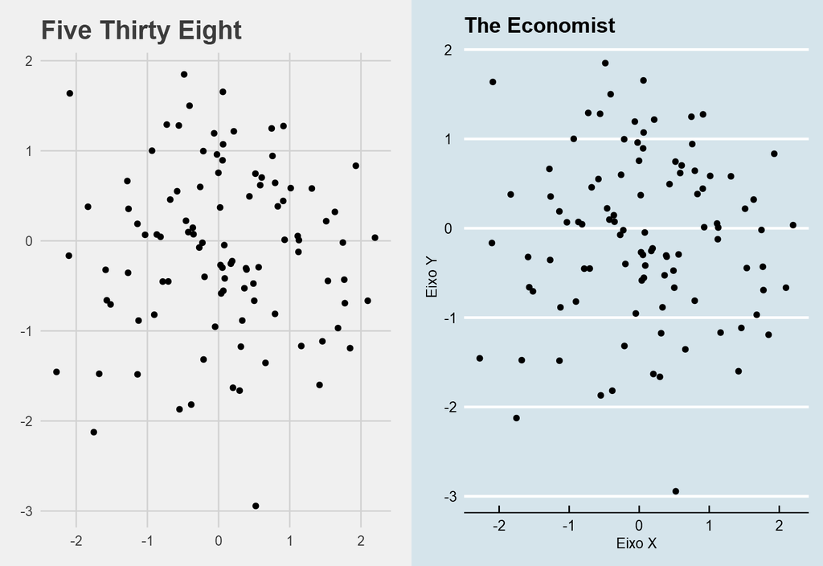

# Introdução ao R: O que ele faz?

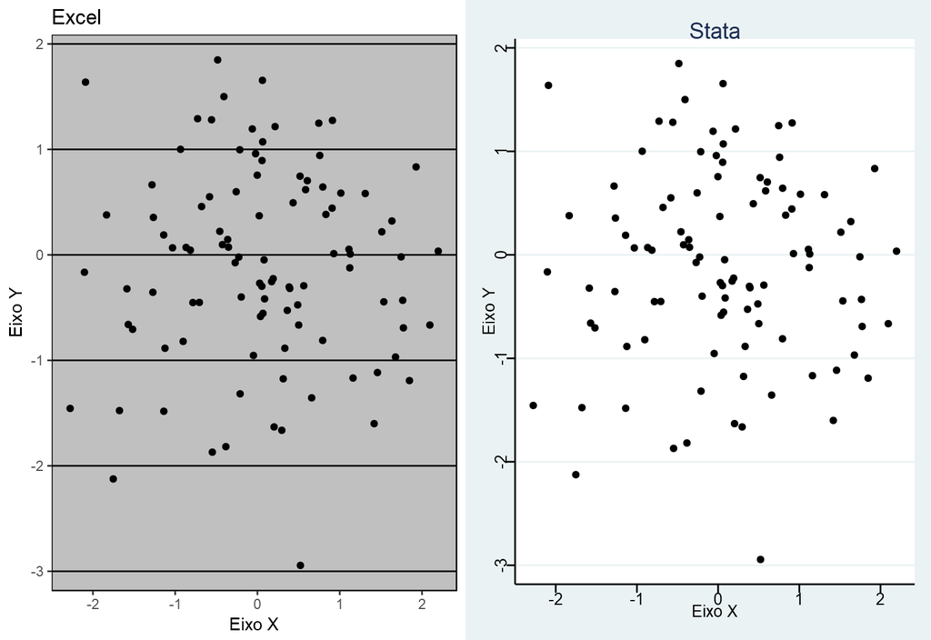

# Introdução ao R: O que ele faz?

[interactive chart not shown]

# Introdução ao R: O que ele faz?

[interactive chart not shown]

# Introdução ao R: O que ele faz?

```r
modelo <- lm(y ~ x + z, data = df)

summary(modelo)
```

```
##
## Call:
## lm(formula = y ~ x + z, data = df)
##
## Residuals:
##      Min       1Q   Median       3Q      Max
## -2.93845 -0.53481  0.05709  0.65081  2.04682
##
## Coefficients:
##              Estimate Std. Error t value Pr(>|t|)
## (Intercept) -0.197380   0.132617  -1.488    0.140
## x            0.001527   0.091529   0.017    0.987
## zB           0.191239   0.187086   1.022    0.309
##
## Residual standard error: 0.9321 on 97 degrees of freedom
## Multiple R-squared:  0.01071,    Adjusted R-squared:  -0.009692
## F-statistic: 0.5248 on 2 and 97 DF,  p-value: 0.5933
```

# Introdução ao R: O que ele faz?

|  | Estimativa | Erro-padrão | T-valor | P-valor |
| --- | --- | --- | --- | --- |
| (Constante) | -0.1974 | 0.1326 | -1.49 | 0.1399 |
| x | 0.0015 | 0.0915 | 0.02 | 0.9867 |
| zB | 0.1912 | 0.1871 | 1.02 | 0.3092 |

# Introdução ao R: O que ele faz?

Até mesmo estes slides foram feitos no R.

# Introdução ao R: Academia

Na academia, o R [já é o segundo ambiente estatístico mais usado](http://r4stats.com/articles/popularity/). Entre outros, ele permite:

- Criar, manipular bancos de dados em qualquer formato e, virtualmente, de qualquer tamanho (*big data*);
- Com seus 9.411 pacotes (em outubro de 2016), ele fornece ferramentas estatísticas e econométricas para todo tipo análise: qualitativa, descritiva, regressões, séries temporais, experimentos e quase-experimentos, randomização, simulações, análise bayesiana, etc.;
- Ele também permite exportar facilmente resultados para qualquer formato: .doc, .xlx, .pdf, `LaTex`, `HTML`, imagem, vídeo, bancos de dados, etc.

# Introdução ao R: Academia

Outras vantagens é que o R:

- É gratuíto;
- E envolve uma comunidade extensa de desenvolvedores que a cada dia implementam novas soluções.

# Introdução ao R: Academia

Entre outros, nas Ciências Sociais já existem diversos usos para o R:

- Estimação de pontos ideais (nominate e derivados);
- Pacotes que permitem acessar dezenas de bancos de dados na área diretamente (psData);
- Pacote que conectam a diversas API ([como a de registro nos EUA](https://github.com/rOpenGov/federalregister));
- Ou o que conecta ao Repositório de Dados Eleitorais do TSE ([electionsBR](https://github.com/silvadenisson/electionsBR/)).

# Análises por georreferenciamento

[Deslocamentos áereos dos(as) Deputados(as) Federais em 2016](https://pbs.twimg.com/media/C0N3Yf2XAAEd08g.jpg:large)

# Análises preditivas

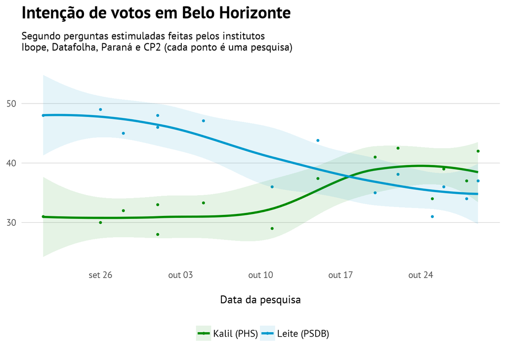

# Análises de sentimentos

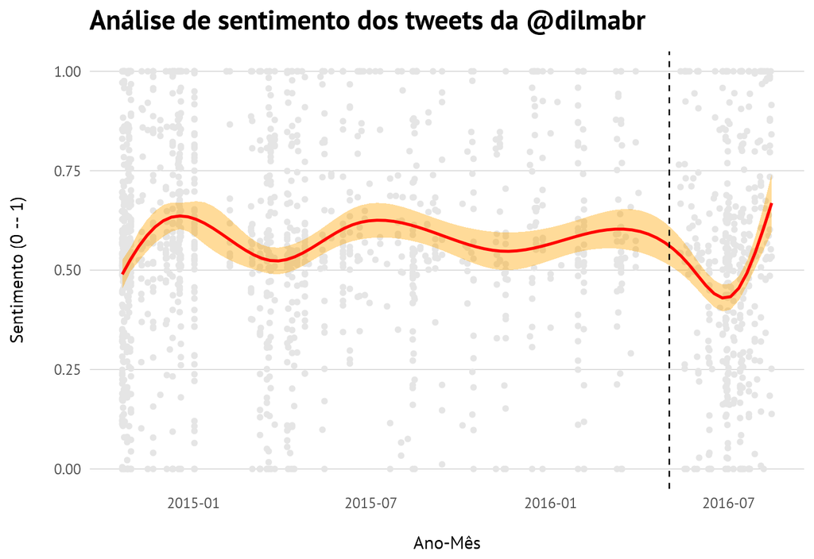

# Experimentos e quase-experimentos

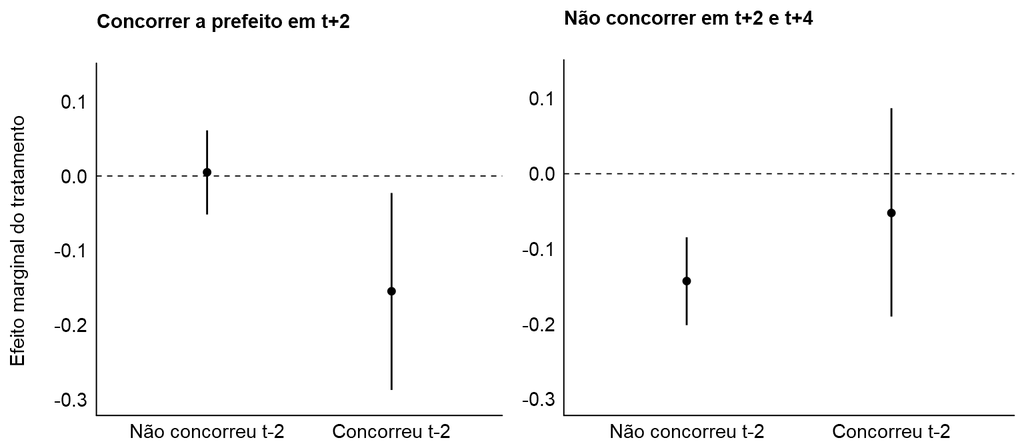

# Webscraping e webcrawiling.

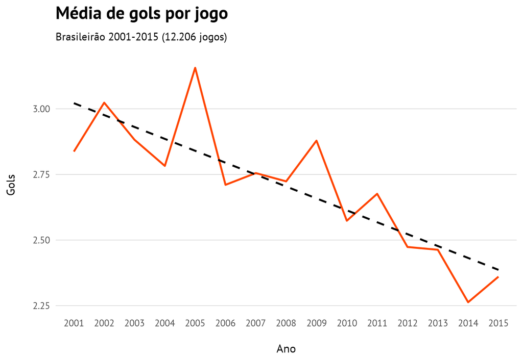

# Objetivos da oficina

- Primeiro, aprenderemos o básico da sintaxe do R, o que chamaremos aqui de *gramática*;
- Depois, trabalharemos com os principais *verbos* usados numa análise;
- Por fim, praticaremos nossa capacidade de articular sintaxe e verbos para produzir análises – a nossa capacidade de falar via R.

# Plano das aulas

- Aula 1 - Básico;
- Aula 2 - Manipulação;
- Aula 3 - Visualização;
- Aula 4 - Exportação.

# Slides e outros materiais

Scripts, leituras, materiais de apoio e etc. estarão em:

`Introducao_ao_R_Modus.zip`